# Briefing, Practice, and Progress: A New Tutorial System

# Overview

Current tutorial system not loved(?)

New proposal: **Briefing**, **Practice**, **Progress**

Aims:

- Improve engagement
- Build skills
- Reduce workload

# “Briefing”

Weekly, zoom-based, whole-cohort meetings (15-30 minutes)

Consistent: Monday 10am

Goals:

- Build community
- Orient students to weekly tasks, deadlines, expectations
- Introduce ‘practice’ tasks
- Reflect on previous week’s tasks

# “Practice”

Weekly, small, structured tasks (15-30 mins max)

Goals:

- Develop positive study habits
- Engage with essential academic and personal skills
- Make automated feedback possible
- Provide a simple metric for engagement

Themes: **Studying**, **Thinking**, **Writing**, **Speaking**, & **Growth**

# “Progress”

- Tutors meet students twice per semester
- 45 minutes, in pairs/threes
- Agenda is student led (a task for them)

# What will you need to do?

5 progress meetings each year (in pairs/threes)

- Briefly review online system in advance
- Typically < 20hours per year | 75% attendance

[maybe] Help create practice tasks

[maybe] Make announcements in some briefings

## How does this compare?

Current stage 1: 1578 staff hours in total

New scheme:

- Briefings: 45 hours.
- Practice: ~300 hours to develop in year 1; plus time to administer Psylab, automated feedback.
- Progress: ~812 hours (max)

# Examples

## *“Fill in the blanks”*

Student needs to write a missing parapgraph in a student essay, based on information provided about an empirical study.

**Mechanics:**

- Materials (instructions, docs, short video, **Psylab** task) released at 9am
- Students review material
- Join Zoom for the **briefing** at 10am
- Submit work (via Psylab) during the week
- Semi-automated feedback before next briefing

## Progress Meetings

45 minutes (15 minutes tutor preparation)

Student-led (previous week they write an agenda)

In pairs/threes, booked with tutors through the DLE

Suggested content:

- Check wellbeing and provide ‘important’ reminders
- Review practice and engagement metrics
- Discuss practice tasks in detail
- Review coursework and feedback
- Reflect on past performance and set future goals

# “Practice & Progress”

Online System

Provide a single, useful view of a student

Structure/streamline logging interactions with students

Connect-to/extend Psylab and S4 (share data)

NOT required; not available in year 1 anyway.

# Roles

- **Senior Tutor**: Oversight of pastoral issues, tutor progress
- **Briefing Lead**: Deliver briefings; coordinate content each week
- **Practice & Progress Lead**: Develop practice tasks and online system
- **Practice Writing Team**: Create and refine practice tasks; develop online materials (akin to RMinR).

# Next

- Thoughts on the plan (Discourse thread)
- Ideas for the tasks

# Thoughts on practice tasks

## Writing

- “Fill in the gaps” (scaffolded practice)
- “ChatGPT, help me write good”
- Being a good editor

## Studying

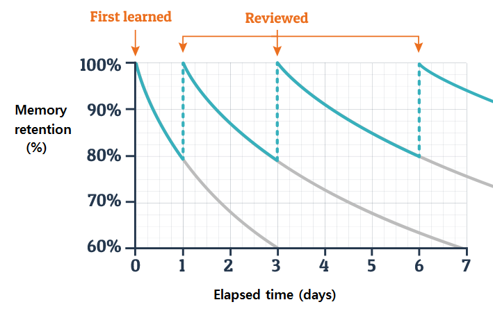

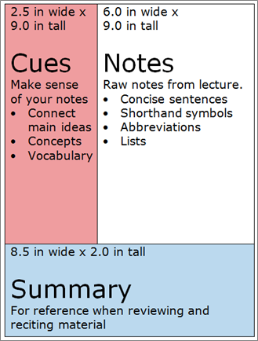

[figure not shown]

- Set up Anki (spaced repetition app)
- Use Cornell notetaking for one lecture
- Install Zotero and share a paper with your tutor
- Make a day-by-day revision plan

## Thinking

- “Spot the deliberate mistake week” (with prize)
- Peer review a “fellow student’s” report
- Hierarchy of evidence: Rank 5 different sources.

## Speaking

[figure not shown]

- “Review” a chunk of a lecture
- Explain a paper (2 minutes phone video)

## Growth

[figure not shown]

- Make a plan for summer volunteering/work experience.
- Respond to feedback (from several different assignments: identify common patterns or points to explore).
- Take charge: Create an agenda for the “progress” meeting; make minutes and share them after.